# PM566 Lab 4

Author

Chih-Chan Jessica Lan

```r
library(data.table)
library(leaflet)
library(tidyverse)
```

# Step 1: Read in the data

```r
if (!file.exists("met_all.gz"))
  download.file(
    url = "https://raw.githubusercontent.com/USCbiostats/data-science-data/master/02_met/met_all.gz",
    destfile = "met_all.gz",
    method   = "libcurl",
    timeout  = 60
    )
met <- data.table::fread("met_all.gz")
```

# Step 2: Prepare the data

```r
met <- met[temp > -17][elev == 9999.0, elev := NA]

met <- met[, week := week(as.Date(paste(year, month, day, sep = "-")))]

met <- met[week == min(week, na.rm = T), ]

met_avg <- met[,.(temp = mean(temp, na.rm = T),
                  rh = mean(rh, na.rm = T),
                  wind.sp = mean(wind.sp, na.rm = T),
                  vis.dist = mean(vis.dist, na.rm = T),
                  dew.point = mean(dew.point, na.rm = T),
                  lat = mean(lat),
                  lon = mean(lon),
                  elev = mean(elev, na.rm = T)),
               by = "USAFID"]

met_avg$region <- ifelse(met_avg$lon > -98 & met_avg$lat > 39.71, "Northeast",
                         ifelse(met_avg$lon > -98 & met_avg$lat < 39.71, "Southeast",
                                ifelse(met_avg$lon < -98 & met_avg$lat > 39.71, "Northwest", "Southwest")))

met_avg$elev_cat <- ifelse(met_avg$elev > 252, "high", "low")

summary(met_avg)
```

```
     USAFID            temp              rh           wind.sp
 Min.   :690150   Min.   : 7.927   Min.   :13.76   Min.   : 0.04306
 1st Qu.:722124   1st Qu.:22.222   1st Qu.:64.68   1st Qu.: 1.27180
 Median :723320   Median :24.145   Median :74.28   Median : 1.95873
 Mean   :723410   Mean   :24.306   Mean   :70.22   Mean   : 2.10606
 3rd Qu.:725148   3rd Qu.:26.358   3rd Qu.:80.55   3rd Qu.: 2.78595
 Max.   :726813   Max.   :39.918   Max.   :96.01   Max.   :11.56875
                                                   NA's   :13
    vis.dist       dew.point           lat             lon
 Min.   : 4558   Min.   :-3.411   Min.   :24.56   Min.   :-124.29
 1st Qu.:14188   1st Qu.:14.897   1st Qu.:33.90   1st Qu.: -99.12
 Median :15335   Median :18.156   Median :38.06   Median : -91.74
 Mean   :14877   Mean   :17.385   Mean   :37.70   Mean   : -92.63
 3rd Qu.:15954   3rd Qu.:20.993   3rd Qu.:41.69   3rd Qu.: -82.56
 Max.   :93592   Max.   :25.439   Max.   :48.94   Max.   : -68.31
 NA's   :25
      elev           region            elev_cat
 Min.   : -12.0   Length:1575        Length:1575
 1st Qu.:  90.0   Class :character   Class :character
 Median : 238.0   Mode  :character   Mode  :character
 Mean   : 416.1
 3rd Qu.: 403.3
 Max.   :4111.3
```

# Step 3: Use `geom_violin` to examine the wind speed and dew point by region

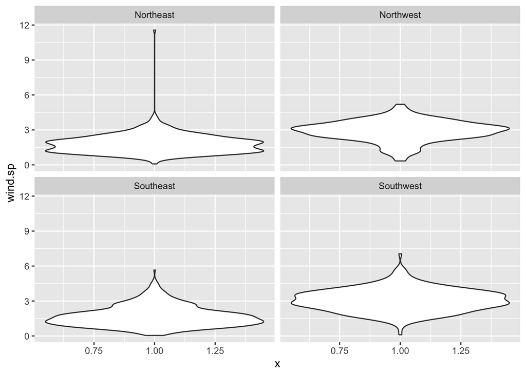

```r
met_avg[!is.na(met_avg$wind.sp) & !is.na(met_avg$region), ] %>%
  ggplot() +
  geom_violin(aes(x = 1, y = wind.sp)) +
  facet_wrap(~ region, nrow = 2)
```

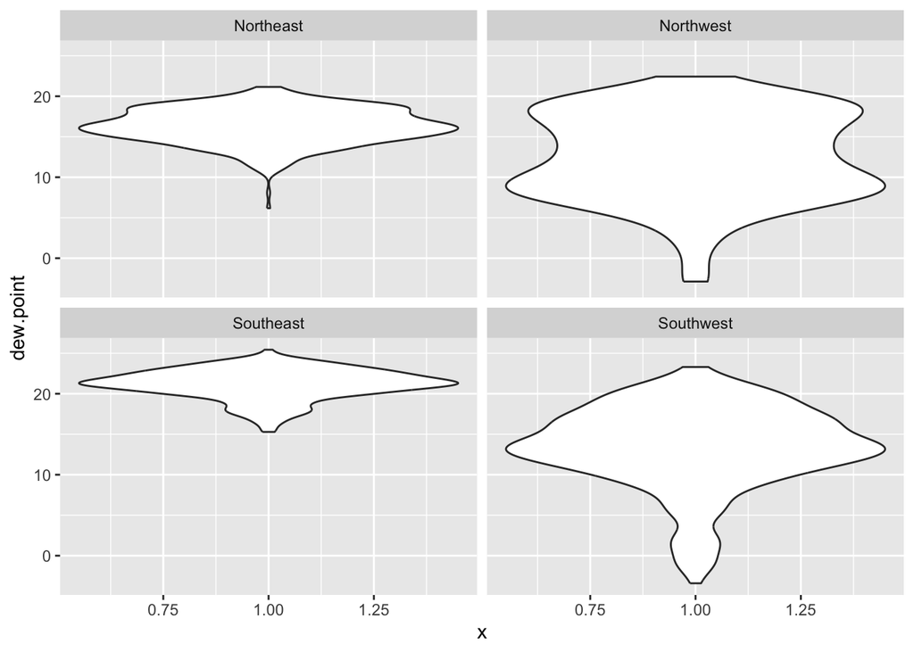

```r
met_avg[!is.na(met_avg$dew.point) & !is.na(met_avg$region), ] %>%
  ggplot() +
  geom_violin(aes(x = 1, y = dew.point)) +
  facet_wrap(~ region, nrow = 2)
```

**Description:** The violin plots reveal distinct regional patterns in dew point distribution. The Northeast region shows dew points mainly between 10–20°C, with some lower outliers. The Northwest region displays a bimodal distribution, with two peaks clustered around 10°C and 20°C. The Southeast region exhibits a concentrated distribution, with dew points consistently around 21°C. The Southwest region demonstrates a broader and smoother spread, with values centered near 15°C. Overall, the Southeast tends to have the highest and most stable dew points, while the Northwest and Southwest show greater variation.

# Step 4: Use `geom_point` with `stat_smooth` to examine the association between dew point and wind speed by region

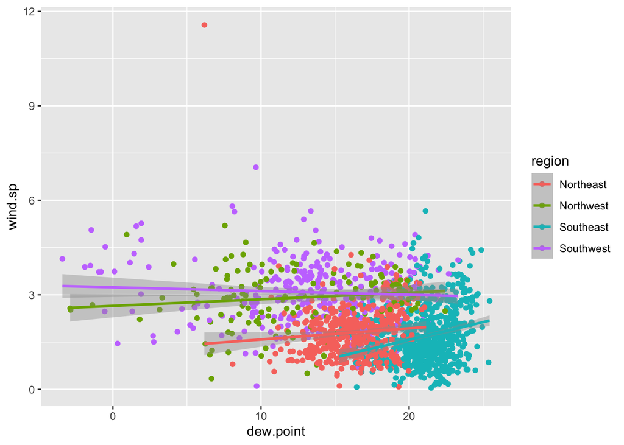

```r
met_avg[!is.na(met_avg$dew.point) & !is.na(met_avg$wind.sp) & !is.na(met_avg$region), ] %>%
  ggplot(aes(x = dew.point, y = wind.sp, color = region)) +
  geom_jitter() +
  stat_smooth(method = lm)
```

**Description:** The scatter plot demonstrates the relationship between dew point and wind speed across all regions. Most regional regression lines are nearly flat, indicating that wind speed remains relatively stable as dew point increases. However, the Southeast region exhibits a more noticeable positive relationship, suggesting that wind speed tends to rise more clearly with higher dew points.

# Step 5: Use `geom_bar` to create barplots of the weather stations by elevation category colored by region

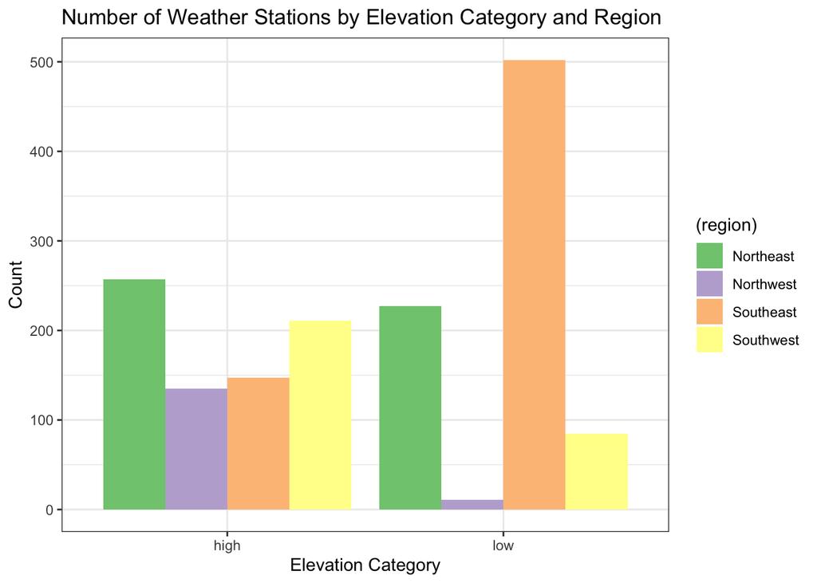

```r
met_avg[!is.na(met_avg$elev) & !is.na(met_avg$region), ] %>%
  ggplot() +
  geom_bar(aes(elev_cat, fill = (region)), position="dodge") +
  scale_fill_brewer(palette = "Accent") +
  labs(title = "Number of Weather Stations by Elevation Category and Region",
       x = "Elevation Category", y = "Count") +
  theme_bw()
```

**Description:** The bar chart reveals significant differences in weather station distribution across regions and elevation categories. The Southeast region has the highest number of stations overall, particularly concentrated at low elevations. The Northeast region shows more stations at high elevations compared to other regions, which likely reflects its mountainous terrain and greater elevation variation. The Northwest region has the fewest total stations but shows a relatively higher proportion at high elevations. This distribution pattern suggests that regional geography strongly influences where weather stations are located.

# Step 6: Use `stat_summary` to examine mean dew point and wind speed by region with standard deviation error bars

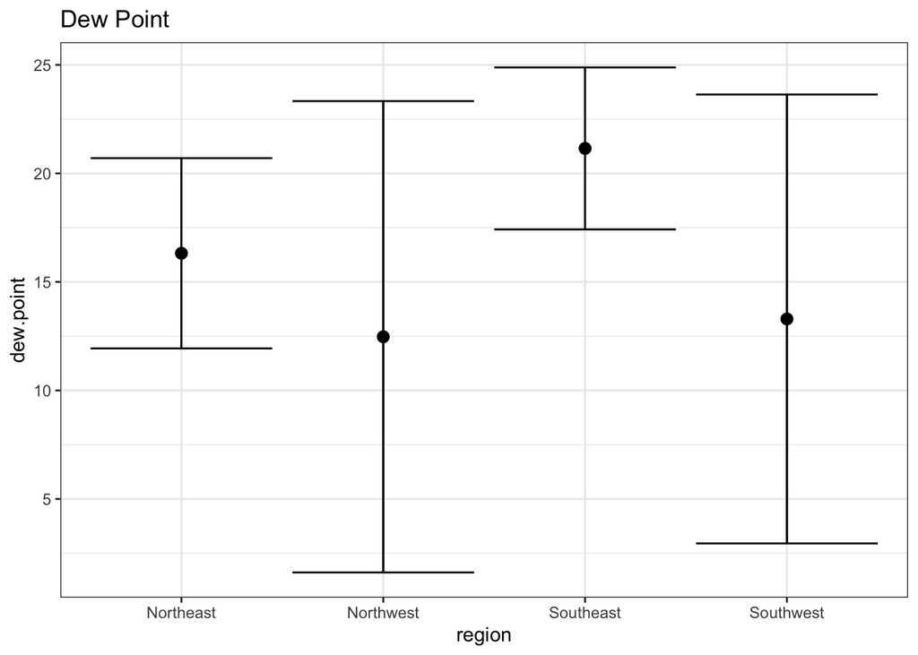

```r
met_avg[!is.na(met_avg$dew.point), ] %>%
  ggplot(aes(x = region, y = dew.point)) +
  stat_summary(fun.data = "mean_sdl", geom = "errorbar") +
  stat_summary(fun.data = "mean_sdl") +
  labs(title = "Dew Point") +
  theme_bw()
```

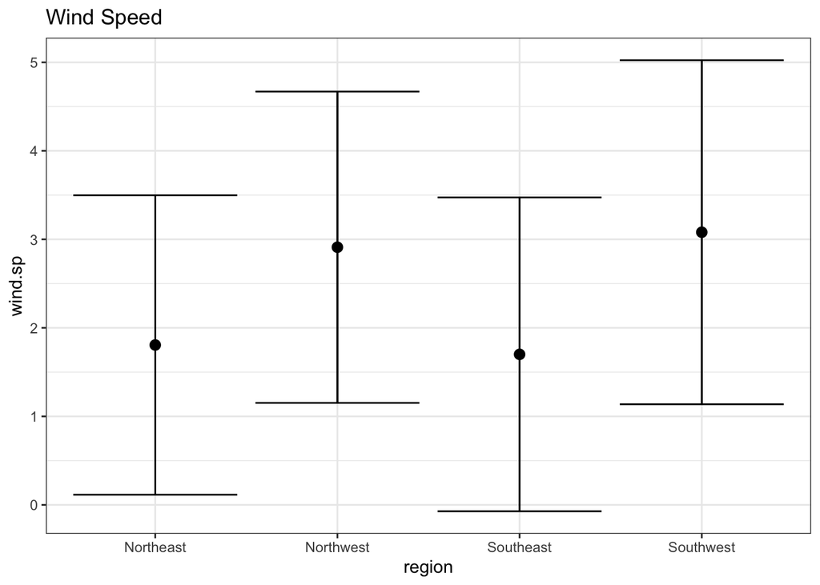

```r
met_avg[!is.na(met_avg$wind.sp), ] %>%
  ggplot(aes(x = region, y = wind.sp)) +
  stat_summary(fun.data = "mean_sdl", geom = "errorbar") +
  stat_summary(fun.data = "mean_sdl") +
  labs(title = "Wind Speed") +
  theme_bw()
```

**Description:** Dew Point: The Southeast region has the highest mean dew point (approximately 21°C), indicating consistently warm and humid atmospheric conditions. The Northwest region shows the lowest mean dew point around 12.5°C, suggesting a cooler and drier climate. The error bars reveal that the Northwest has the most variable conditions, while the Southeast remains more stable, reflecting regional climatic differences.

Wind Speed: The Southwest region has the highest mean wind speed (around 3 m/s), indicating generally windier conditions. The Southeast region shows the lowest mean wind speed about 1.8 m/s, suggesting calmer atmospheric conditions. The error bars reveal that the Southwest also exhibits the greatest variability, while the Northeast and Southeast remain more stable.

# Step 7: Make a map showing the spatial trend in relative humidity in the US

```r
met_avg2 <- met_avg[!is.na(rh), ]
top10 <- met_avg[rank(-rh) <= 10]
rh_pal = colorNumeric(c('blue', 'purple', 'orange'), domain = met_avg2$rh)

leaflet(met_avg2) %>%
  addProviderTiles('OpenStreetMap') %>%
  addCircles(lat = ~lat, lng = ~lon, color = ~rh_pal(rh),
             label = ~paste0(round(rh, 2), 'rh'), opacity = 1, fillOpacity = 1, radius = 500) %>%
  addMarkers(lat = ~lat, lng = ~lon, label = ~paste0(round(rh, 2), 'rh'), data = top10) %>%
  addLegend('bottomleft', pal = rh_pal, values = met_avg2$rh,
            title = 'Relative Humidity', opacity = 1)
```

[interactive chart not shown]

# Step 8

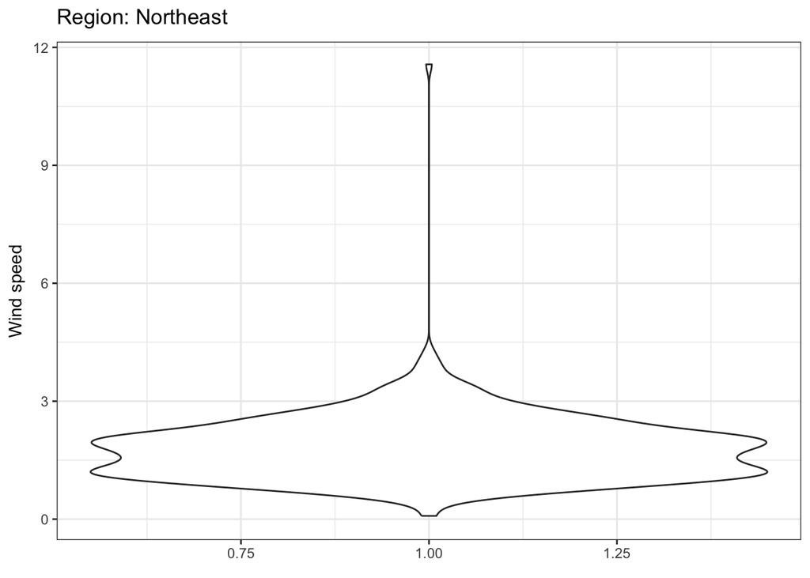

```r
library(gganimate)

met_avg[!is.na(met_avg$wind.sp) & !is.na(met_avg$region), ] %>%
  ggplot(aes(x = 1, y = wind.sp)) +
  geom_violin() +
  labs(x = NULL, y = "Wind speed",
       title = "Region: {closest_state}") +
  theme_bw() +
  transition_states(
    states = region,
    transition_length = 2,
    state_length = 1,
    wrap = F
  ) +
  enter_fade() +
  exit_shrink() +
  ease_aes('sine-in-out')
```